# American Journal of Botany

[American Journal of Botany](https://bsapubs.onlinelibrary.wiley.com/journal/15372197)

[Volume 105, Issue 11](https://bsapubs.onlinelibrary.wiley.com/toc/15372197/2018/105/11) p. 1835-1846

[figure not shown]

Research Article

Free Access

# Consequences of multiple flower–insect interactions for subsequent plant–insect interactions and plant reproduction

[Nicole L. Soper Gorden](https://bsapubs.onlinelibrary.wiley.com/authored-by/ContribAuthorRaw/Soper+Gorden/Nicole+L.),

[Lynn S. Adler](https://bsapubs.onlinelibrary.wiley.com/authored-by/ContribAuthorRaw/Adler/Lynn+S.),

First published: 30 October 2018

https://doi.org/10.1002/ajb2.1182

Citations: 4

## Abstract

### Premise of the Study

Plants often interact simultaneously with multiple antagonists and mutualists that can alter plant traits at the phenotypic or genetic level, subsequent plant–insect interactions, and reproduction. Although many studies have examined the effects of single floral antagonisms on subsequent pollination and plant reproduction, we know very little about the combined, potentially non-additive effects of multiple flower–insect interactions.

### Methods

We simulated increased florivory, nectar robbing, and pollination on field-grown *Impatiens capensis*, which allowed us to determine interactive effects on five subsequent plant–insect interactions and 16 plant traits, including traits related to plant growth, floral attractiveness, floral defenses, and plant reproduction.

### Key Results

All three manipulative treatments had significant non-additive effects on the behavior of subsequent floral visitors, indicating that the effect of floral visitors generally depended on the presence or behavior of others. Pollination increased visitation by both pollinators and nectar larcenists (robbers and thieves), while florivory reduced pollinator and larcenist visits. Surprisingly, supplemental pollination also increased leaf herbivory. Florivores often responded to manipulations in opposite ways than did nectar larcenists and pollinators, suggesting different mechanisms influencing visitors that consume nectar compared to floral tissue. While our treatments did not affect any floral trait measured, they non-additively impacted plant reproduction, with florivory having a larger overall impact than either nectar robbing or pollination.

### Conclusions

These results emphasize the importance of understanding the context in which flower–insect interactions occur because the composition of the interacting community can have large and non-additive impacts on subsequent insect behavior and plant reproduction.

Plants often interact with a wide range of antagonists and mutualists simultaneously, and their combined effects may not be accurately predicted by studies manipulating single species (e.g., Strauss and Irwin, 2004; Morris et al., 2007; Terhorst et al., 2018). Thus, there has been recent interest in studying plant–insect interactions in a broader community context to better understand the ecological and evolutionary impacts of non-additive effects on plants (i.e., statistically significant interactions between different treatments; Strauss and Irwin, 2004; Ashman and Penet, 2007; Morris et al., 2007; Rodríguez-Rodríguez et al., 2017; Terhorst et al., 2018). For example, pollinators increase plant reproduction of *Sinapsis arvensis* only when pollen beetles are absent (Grass et al., 2018), indicating that the presence of beetles changes the importance of pollination for reproduction. In another system, different functional groups of herbivores feeding on *Brassica nigra* shift the composition of the plant's pollinator community and alter florivore preference (Rusman et al., 2018). The effects of multiple plant-using species on plants can subsequently lead to non-additive selection on plant traits (reviewed by Terhorst et al., 2018). These studies and others (e.g., Garcia-Callejas et al., 2018; Knauer et al., 2018; Tsuji and Ohgushi, 2018) demonstrate the importance of considering community context when investigating plant ecology and evolution and making predictions about how changes in community composition will affect plants.

Due to their importance for plant reproduction, floral interactions have the potential for large impacts on plants. Although flowers are often damaged by multiple floral antagonists, the combined effects of such interactions are largely unknown, since floral antagonists are studied much less frequently than leaf antagonists (McCall and Irwin, 2006; Irwin et al., 2010). While many floral antagonists individually reduce plant reproduction (McCall and Irwin, 2006; Agrawal et al., 2007; Irwin et al., 2010; Eliyahu et al., 2015), the effect of one floral antagonist on the behavior of others is a relatively understudied field that may have important consequences for plants. For example, florivory of *Iris bulleyana* causes a bee that usually serves as a pollinator to switch to nectar robbing (Ye et al., 2017). Floral antagonists also alter flower traits. Florivory changes floral symmetry (McCall, 2008), volatile emissions (Lucas-Barbosa et al., 2011), nectar guides (Botto-Mahan and Ojeda-Camacho, 2000), rewards (Krupnick et al., 1999; Missagia and Alves, 2017), display size (Ashman and Penet, 2007; Liao et al., 2013), and resistance traits (McCall, 2006; Kaczorowski et al., 2014; Boyer et al., 2016), all of which could affect the preference of other floral antagonists or mutualists (e.g., Soper Gorden and Adler, 2016). For example, florivory in *Pedicularis gruina* reduces the number of pollinator visits (Liao et al., 2013), further supporting the need to study interactions in a community context.

Typically, studies that include both pollinators and plant antagonists assume that antagonists affect pollinators but not vice versa (e.g., Bronstein et al., 2003; Ivey and Carr, 2005). The few studies that have examined pollinator effects on antagonists typically focus on frugivore or granivore responses to increased fruit/seed production (e.g., Herrera, 2000). Many studies have demonstrated that nectar robbers (e.g., Irwin and Brody, 1998; Temeles and Pan, 2002; Kaczorowski et al., 2014; Missagia and Alves, 2017) and florivores (e.g., Botto-Mahan and Ojeda-Camacho, 2000; Ashman and Penet, 2007; McCall, 2008; Liao et al., 2013) affect pollinator preference. However, research is lacking on whether pollinators can affect floral antagonists in turn. Pollination can alter floral traits in many ways, including changes in flower color (Weiss, 1991; Nuttman and Willmer, 2003; Ruxton and Schaefer, 2016), floral sex ratio (Sato, 2002), scent (Lucas-Barbosa et al., 2016), shape (van Doorn, 1997), and longevity (Ashman and Schoen, 1997; van Doorn, 1997; Sato, 2002). These changes can often make flowers less attractive to subsequent pollinators (Weiss, 1991; van Doorn, 1997; Sato, 2002; Nuttman and Willmer, 2003; Lucas-Barbosa et al., 2016). Since many floral antagonists are attracted to the same traits as pollinators (Temeles and Pan, 2002; McCall and Irwin, 2006; Irwin et al., 2010; Nunes et al., 2016), pollination could also reduce attractiveness to subsequent floral antagonists. Additionally, some plant species can alter resource allocation to future flowers based on pollination quality (e.g., Albert et al., 2011; Canto et al., 2011), which could influence attractiveness to floral antagonists as well as future pollinators.

In addition to attractive traits, flowers may produce chemical defenses, sometimes at higher concentrations than in leaves (Zangerl and Rutledge, 1996; Strauss et al., 2004; Frölich et al., 2007; Cook et al., 2013). Both petals (e.g., Euler and Baldwin, 1996; Strauss et al., 2004) and nectar (Adler and Irwin, 2005; Adler et al., 2006; Kaczorowski et al., 2014; Richardson et al., 2015) can contain the same defenses that frequently deter leaf herbivores, and other flower parts (e.g., pollen, ovules, stigmas) can contain high levels of defenses (Gronquist et al., 2001; Frölich et al., 2007). Floral chemical defenses have been implicated in deterring antagonists such as florivores (Johnson et al., 2008; Lucas-Barbosa et al., 2011), seed predators (McArt et al., 2013), and nectar larcenists (Adler and Irwin, 2005; Kaczorowski et al., 2014), but also deter some pollinators (e.g., Adler and Irwin, 2005; Lucas-Barbosa et al., 2011; Adler and Irwin, 2012; but see Kessler et al., 2008), causing possible ecological trade-offs. Floral chemical defenses can be induced after leaf herbivory (Euler and Baldwin, 1996; Adler et al., 2006; McCall and Karban, 2006; McArt et al., 2013; Lucas-Barbosa, 2016), and some plants display induced resistance to florivores after floral damage (McCall, 2006; Kaczorowski et al., 2014; Boyer et al., 2016; but see Soper Gorden and Adler, 2016). Understanding how floral mutualists and antagonists alter both attractive and defensive floral traits has important implications for understanding how these relationships shape the subsequent community of plant–insect interactions.

Although it may be difficult to predict the outcome of interactions in complex communities where non-additive effects are likely (Morris et al., 2007; Strauss, 2014), we can make some predictions based on how different insects interact with flowers (Fig. 1). While florivores and nectar robbers are both generally considered antagonists, they affect flowers in different ways (Eliyahu et al., 2015). For example, both damage petal tissue, but florivores can alter flower size and symmetry (McCall, 2008; Liao et al., 2013; Soper Gorden and Adler, 2016; Jogesh et al., 2017) while nectar robbers reduce nectar volume (Hazlehurst and Karubian, 2016; Missagia and Alves, 2017). We predict that florivory effects will mask nectar-robbing effects when pollinators are making visitation decisions since symmetry and size are more likely to be noticed at a distance before pollinators are close enough to notice nectar volume differences (Brody and Mitchell, 1997; Chittka and Raine, 2006; Wignall et al., 2006). As a result, nectar robbing would only affect pollinator visitation when florivory is low or absent (Fig. 1A), a pattern that may translate into non-additive effects on plant reproduction. Since pollinators are mutualists directly involved in plant reproduction, plants may be able to compensate for the negative effects of antagonists by maintaining pollinator visitation through refilling robbed nectar, changing when or which flowers are aborted, altering floral scent, or other mechanisms. For example, florivores often reduce plant reproduction (Washitani et al., 1996; McCall, 2008; Grass et al., 2018), but if flowers can maintain sufficient pollination via one of these mechanisms (provided florivores do not damage reproductive parts), then a non-additive pattern would result where florivory only affects plants negatively when pollinators are rare (Fig. 1B). In *Impatiens pallida*, damaging petals and changing floral symmetry does not alter female fitness (Frey et al., 2005), suggesting that flowers are attractive enough to get sufficient pollination despite floral damage. Since flower–insect interactions can alter floral traits and both floral antagonists and floral mutualists can respond to the same floral traits (e.g., Nunes et al., 2016), floral traits may be prone to opposing selection when multiple insect interactions are present (Strauss and Irwin, 2004). However, increasing community complexity often leads to more diffuse effects on plant fitness (Strauss and Irwin, 2004; Haloin and Strauss, 2008), such that we may see stronger effects of single plant–insect interactions on plant reproduction than when several community members are present.

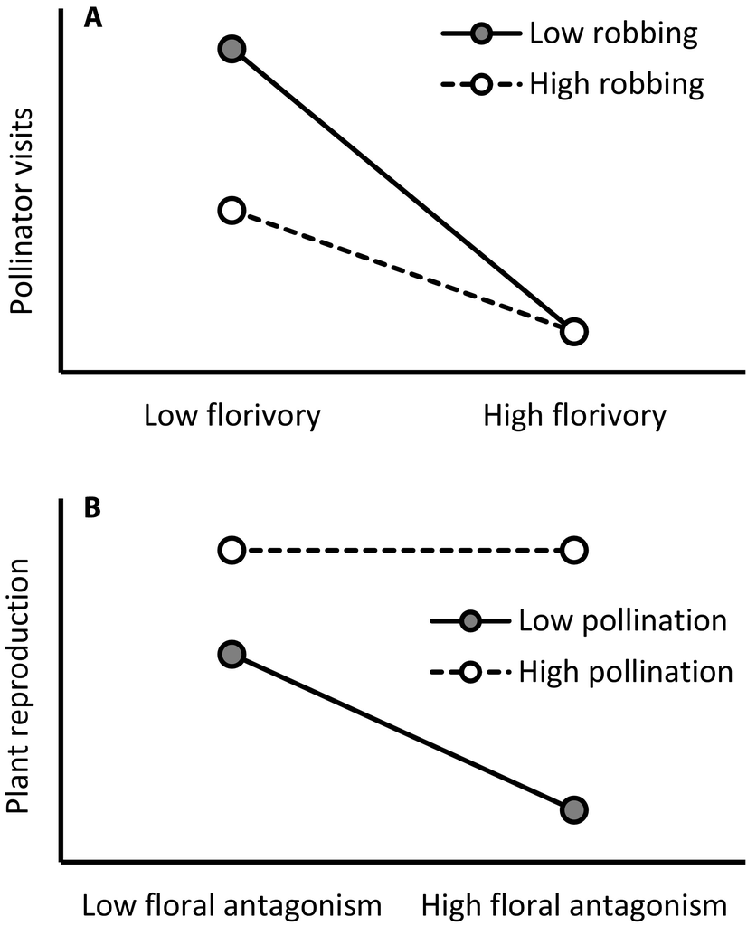

**Figure 1**

Example hypotheses demonstrating non-additive effects of multiple insects interacting with flowers. (A) If pollinators perceive florivore damage from a distance and nectar robbing only at close range, pollinator visitation may be low on plants with high levels of florivory regardless of nectar robbing, and only negatively affected by high nectar robbing when florivory is low. (B) If high pollination can compensate for the effects of floral antagonists, negative effects of florivores or nectar robbers may be strongest when pollination is low.

We conducted a factorial manipulation of florivory, nectar robbing, and pollination to test their combined effects on floral attractive and defense traits, subsequent plant–insect interactions, and plant reproduction in the field. While we have previously manipulated florivory to measure its effects on a similar suite of responses (Soper Gorden and Adler, 2016), this study manipulates three flower–insect interactions, allowing tests for non-additive effects between different treatments due to multi-way statistical interaction terms that cannot be detected in pairwise studies. The results from this study provide a comprehensive picture of how multiple floral interactions affect plant reproduction via changes in subsequent visitation and/or floral traits and may be important for understanding factors that influence yield in crop systems that rely on pollination but also experience floral antagonisms (e.g., nectar robbers on the blueberry *Vaccinium corymbosum*; Rogers et al., 2013).

## Materials and Methods

### Study system

*Impatiens capensis* Meerb. (Balsaminaceae) is an annual found in moist soils in much of North America (Leck, 1979; Eastman, 1995). It has a mixed mating system, with selfing cleistogamous (CL) and open-pollinated chasmogamous (CH) flowers; the showy orange CH flowers produce more seeds with better dispersal and survival than seeds from CL flowers (Mitchell-Olds and Waller, 1985; Schmitt et al., 1985). Chasmogamous flowers are heavily reliant on pollinators, mostly *Bombus* sp. and *Apis mellifera*, to produce fruits (Rust, 1977; Leck, 1979; Eastman, 1995). Both flower types produce a capsule fruit containing one to several seeds, which are dispersed explosively as the fruit ripens. The seed bank generally does not last more than 1 year (Simpson et al., 1985).

Besides pollinators, several floral antagonists visit CH flowers. Nectar robbers and nectar thieves both consume nectar without contacting the plant's reproductive parts (Rust, 1979; Soper Gorden and Adler, 2013, 2016); while nectar robbers pierce the corolla or spur to consume nectar, nectar thieves are simply too small to transfer pollen when entering the corolla opening (Irwin et al., 2010). Collectively, nectar robbers and nectar thieves are considered nectar larcenists (Irwin et al., 2010). Chasmogamous flowers can have very high rates of nectar robbing (up to 80% of flowers) by several insect species, including the plant's main pollinators (Eastman, 1995; Young, 2008). Although some robbers can also be pollinators, CH flowers are never pollinated during the act of robbing (Rust, 1979). Nectar robbers include *Vespula maculifrons*, *Apis mellifera*, and some *Bombus* species (Rust, 1979). Nectar thieves include halictid bees, syrphid flies, and ants (Eastman, 1995). Finally, generalist herbivores, including *Popillia japonica*, regularly consume CH flowers as florivores (0–90% damage; Soper Gorden and Adler, 2013, 2016).

Chasmogamous flowers have a range of attractive and defense traits. Plants vary in number of flowers, flower size, nectar production, and flower height (Soper Gorden and Adler, 2013, 2016). Chasmogamous flower color can vary from entirely yellow (no red spotting) to almost entirely red (extensive red spotting; Boyer et al., 2016). Both vegetative and floral tissues contain anthocyanins and condensed tannins that may alter interactions with plant-visiting insects (Boyer et al., 2016; Soper Gorden and Adler, 2016). Anthocyanins are flavonoid pigments that often attract pollinators (Delpech, 2000; Koes et al., 2005), but have also been implicated in reducing florivore preference and performance (Johnson et al., 2008). Anthocyanins are present in *Impatiens* spp. leaves, CH flowers, and stems, and cause the variable red spots on the lip petals of *I. capensis* (Aras et al., 2007). Condensed tannins are also present in *Impatiens* spp. in general (Waterman et al., 1983) and *I. capensis* CH flowers specifically (Boyer et al., 2016; Soper Gorden and Adler, 2016). Although condensed tannins are usually studied as vegetative defenses, they are also found in floral tissue and have the potential to deter florivores (Burggraaf et al., 2008).

### Plant propagation and treatments

On 6 May 2011, we collected *I. capensis* seedlings from Hampshire Farm (42°19′N 72°31′W), transplanted them into 10-cm pots in Fafard #2 mix (Conrad Fafard, Agawam, MA, USA), and kept them in a greenhouse under natural light on the University of Massachusetts campus (42°23′N W 72°32′W) until they were planted in the field. Plants were watered daily and bench locations were randomized once a week. On 15 June 2011, when all plants were ~0.4 m tall, we transplanted 200 plants along the northwest edge of a wet forest at Hampshire Farm where *I. capensis* occurs naturally. Plants were in four rows of 50, with each plant 1 m from all neighbors. To reduce intraspecific competition, we removed naturally occurring conspecifics within 0.25 m of each plant.

Our three treatments (florivory, nectar robbing, and pollination) were randomly applied in a fully factorial manner, resulting in eight total treatment combinations, including an unmanipulated control group; each treatment combination was applied to 25 plants. Treatments were applied every day once each plant began producing CH flowers (between 5 July and 25 August, depending on plant) until the first hard frost in the fall (September 28). Occasionally, a day was missed due to inclement weather, but there was never more than 2 days between treatment applications. All plants also received natural levels of florivory, nectar robbing, and pollination. Florivory was manipulated by removing 30% floral tissue from every fourth CH flower using dissecting scissors (average natural florivory at this site; Soper Gorden and Adler, 2016). Control plants did not receive artificial florivory, but naturally received an average of 28% damage on 26% of CH flowers, suggesting our florivory supplement approximately doubled florivory damage. Nectar robbing was manipulated on every fourth CH flower by using dissecting scissors to cut a small hole at the base of the flower's throat (where many nectar robbers puncture the corolla) and a microcapillary tube to remove nectar, which has successfully simulated nectar robbing in other systems (e.g., Irwin and Brody, 1998). Control plants did not receive artificial nectar robbing, but approximately 10% of CH flowers were robbed naturally; both nectar-robbing levels are well within the natural range (Eastman, 1995; Young, 2008). Pollination was manipulated by using a paintbrush to apply mixed pollen from at least three wild plants to stigmas of female-phase CH flowers; since CH flowers only spend 15–20% of their lifespan in the female phase (Temeles and Pan, 2002), approximately 20% of CH flowers received supplemental pollination. Control plants had no additional pollen added, but CH flowers naturally had approximately 25% visitation by pollinators. Florivory and nectar robbing were never applied to the same individual flowers for both treatments; hand pollination was applied to all female-phase flowers on treatment plants each day, even if they had been otherwise manipulated.

We did not include separate handling controls for our treatment manipulations. However, previous unpublished research in this species found no effects of handling or marking flowers on leaf herbivory, pollinator visitation, plant growth, or female reproduction (*P* ≥ 0.20, *n* = 50 for all; Soper Gorden, unpublished data). Additionally, every CH flower produced was handled and marked during counting (see “Responses” section below) and plants were handled extensively during other measurements regardless of treatment. The amount of additional handling due to florivory, nectar robbing, and/or pollination treatments was small compared to the amount of overall handling each plant and CH flower received. Thus, it is highly unlikely that differential handling effects biased our results.

### Responses

Plant growth was measured three times during the summer, including plant height, number of nodes, and leaf area (estimated by multiplying the length and width of the two most apical fully expanded leaves and averaging the values). In this species, plant height is significantly correlated with aboveground dry biomass (correlation: df = 173, *r*<sup>2</sup> = 0.61, *P* < 0.0001; Soper Gorden, unpublished data).

All CH flowers were counted at least every other day (flowers last ~2 d before senescing) to provide total lifetime CH flower production. Pedicels of counted CH flowers were marked with Wite-Out Quick Dry (Bic, Clinchy, France) to prevent double counting. CH flower size was measured on up to three flowers per plant five times during the summer by measuring flower length, nectar spur length, lip petal width, and lip petal height. These four morphometric measures were averaged across CH flowers within plant, then condensed into one value using principal components analysis [PCA; prcomp() in R version 2.13.0; R Foundation for Statistical Computing, Vienna, Austria]. The first significant principal component (PC1) explained 66% of the total variation and was used to represent CH flower size for analysis. Nectar production was measured on up to three CH flowers per plant, bagged as buds to prevent pollinator visitation. Nectar was collected from male-phase CH flowers approximately 12 h after the flower opened using microcapillary tubes to remove pooled nectar from the base of the throat, then the tip of the nectar spur was cut and any additional nectar squeezed into the same tube. We quantified CH flower color from photographs of the flowers used for defense extractions (see below) using ImageJ's threshold and measure features to calculate the percentage of lip petals that were red versus yellow-orange in color (ImageJ v.1.43, National Institute of Health, 2010). Since CH flower color on each plant is bimodal as yellow or red and does not switch between the two colors, we used the change in flower color, rather than absolute flower color, as our response when assessing whether our treatments affected floral traits. We calculated change in CH flower color by subtracting late season flower color values (after treatment application) from early season flower color values (before treatment application).

Although we marked all CH flower pedicels to count total CH flower production, CL flowers are more cryptic and difficult to find, making it logistically impossible to count using the same methods. While we did count the number of CL flowers per plant three times during the summer, the methods mean that the numbers of CH and CL flowers are not comparable. Furthermore, the number of CL flowers had a low sample size and very non-normal distribution. Adding number of CL flowers to our MANCOVA for plant reproduction (see later “Statistical Analyses” section) did not qualitatively change our results, and there were no treatment effects on CL flowers (data not shown). We therefore did not include CL flower counts in our analyses.

For chemical analysis, we collected the first two CH flowers each plant produced (before treatments were applied; 7 July through 1 September, depending on plant) and two CH flowers later in the season (25 August or after all treatments had been applied at least once, whichever came later). These CH flowers were digitally photographed for flower color analysis, then frozen at −80°C until chemical extractions. Floral anthocyanins were extracted from one early and one late CH flower, using a modified protocol (Mancinelli, 1990; Aras et al., 2007; Brusslan, 2007; Soper Gorden and Adler, 2016). Briefly, frozen CH flowers were placed in acidified methanol (1% HCl v/v) at 4°C in the dark for 48 h, removed by filtering, and absorbance of the solution measured at 530 nm and 657 nm with a spectrophotometer (Genesys 10S UV-Vis Spectrophotometer, Thermo-Scientific, Waltham, MA, USA). Relative anthocyanin content was calculated as *A*<sub>530</sub> – 0.25*A*<sub>657</sub>, as per Mancinelli (1990), then standardized by flower mass. Floral condensed tannins were extracted from one early and one late CH flower, using an acid butanol method modified from Hagerman (2002) as in Soper Gorden and Adler (2016). Briefly, frozen CH flowers were ground and sonicated in 70% acetone. The supernatant was added to acid butanol (5% HCl v/v) and 2% ferric ammonium sulfate in 2N HCl, heated in a boiling water bath for 50 min, then measured at 550 nm with the spectrophotometer. Relative condensed tannin content was calculated as *A*<sub>550</sub> standardized by flower mass. Both floral defenses varied widely by plant (~40 fold for anthocyanins and ~140 fold for condensed tannins). To better detect small changes in floral defenses in response to treatments, we subtracted the early season value from the late season value to calculate the change in defense levels over the summer.

Pollinators, nectar robbers, and nectar thieves were observed and counted during 15-min surveys on 8 d spread throughout the summer, resulting in an average of 2–3 observation bouts per plant. Visitor type (pollinator, nectar robber, or nectar thief) was determined through behavioral observations. On two occasions, an insect behaved as both a pollinator and a nectar robber in the same visit and was counted as both. Average visits per 15 min per plant were converted to average visits per hour for analysis. We surveyed herbivory approximately monthly, during which we counted and identified each leaf herbivore on each plant to measure herbivore density and richness (measured as the number of herbivore functional groups), and estimated percentage leaf damage on four apical fully expanded leaves. Due to time constraints, each plant was surveyed for herbivores two or three times; there was no difference between herbivore responses on plants measured twice versus three times (*t*-tests: *P* > 0.3 for all), so herbivore sampling effort was not included in analyses. Finally, we estimated florivory during six surveys every other week, during which we recorded the average percentage floral tissue missing per CH flower for each plant, excluding artificial florivory from our treatments. For all insect measures, we averaged across surveys, giving us one value per insect measure per plant.

Fruits from CH and CL flowers can be distinguished based on size, shape, pedicel length, and location on the plant. We counted both CH and CL fruits during biweekly surveys to estimate CH to CL ratio and the total number of fruits produced. Total fruit production can be counted from pedicel scars from dehisced fruits, but the process is extremely time-consuming, and it is almost impossible to distinguish CH and CL fruits from just the scars. Previous work showed that the average number of fruits per day was highly correlated with the total number of fruits produced up to that point (*n* = 40, *r*<sup>2</sup> = 0.91, *P* < 0.0001; Soper Gorden and Adler, 2013), so the average CH and CL fruits per day was used to estimate total fruit production. During these surveys, we also collected mature CH and CL fruits, stored them at 4°C, counted seeds per fruit, and measured average seed mass. Finally, to test for shifts in mating system, we calculated the proportion of CH versus CL fruits each plant produced by comparing average daily CH and average daily CL fruits per plant.

### Statistical analyses

To test the effects of floral treatments, we conducted five MANCOVAs on groups of related traits: plant growth (height, leaf size, and number of nodes); floral traits (change in anthocyanins, change in condensed tannins, and CH flower size, estimated by PC1 from the flower size PCA); leaf herbivory (leaf damage, density of herbivores, and herbivore richness); plant reproduction (total CH flower production, number of CH and CL fruits, and ratio of CH versus CL fruits); and seed traits (seeds per CH and CL fruit and average mass of CH and CL seeds). For each test, we included florivory treatment, nectar robbing treatment, pollination treatment, and all two- and three-way interaction terms, with the Julian date of first CH flower included as a fixed covariate in all analyses. Additionally, plant height was used as a covariate in the plant reproduction and seed traits MANCOVAs to control for plant size. CH flower production was square root-transformed, and log transformations were used for leaf damage, herbivore density, CH and CL fruit counts, ratio of CH to CL fruits, number of seeds per CL fruit, and average mass of CL seeds to improve normality. All MANCOVAs were conducted in R version 3.2.0 (R Foundation for Statistical Computing) using Manova() with type 3 sums of squares (car package). Individual ANCOVAs were investigated when a MANCOVA was significant.

A few variables had left-shifted distributions that did not have normal error distributions even after transformation: percentage florivory, pollinator visits, nectar robber visits, nectar thief visits, and nectar production. For these responses, we conducted individual generalized linear models (GLIMs) using a Poisson distribution with a log link function, and including florivory, nectar robbing, and pollination treatments and all two- and three-way interactions as explanatory variables, with Julian date of first CH flower as a fixed covariate. Since nectar production showed evidence of overdispersion, we used a Quasipoisson distribution for its analysis. Seasonal change in CH flower redness was extremely non-normal and did not fit a Poisson distribution. Instead, we ran a GLIM using a Gaussian distribution with an identity link. All GLIMs were run in R using glm() (version 3.2.0, R Foundation for Statistical Computing).

## Results

### Effects on plant growth and floral traits

Our treatments did not affect any measure of plant growth or floral traits, including change in CH flower redness or nectar production (Table 1). Date of first CH flower (a covariate) was the only significant effect (Table 1A). Subsequent ANOVAs showed that plants that flowered later tended to be taller (*F*<sub>8, 185</sub> = 15.7805, *P* = 0.0001) and have larger leaves (*F*<sub>8, 185</sub> = 7.6902, *P* = 0.006) and more nodes (*F*<sub>8, 185</sub> = 5.1601, *P* = 0.02).

Table 1. Effects of supplemental florivory, nectar robbing, and pollination on *Impatiens capensis* growth, floral traits, plant reproduction, and subsequent plant–insect interactions. In addition to treatments and their interaction terms, date of first chasmogamous (CH) flower was included as a covariate in all analyses, and plant height was included as a covariate in the reproduction and seed trait analyses. (A) MANCOVA results [(F) P] testing effects on plant growth, floral traits, leaf herbivory, plant reproduction, and seed traits. (B) GLIM results [(*z* or *t*) *P*] on number of pollinator, nectar robber, and nectar thief visits per h, subsequent natural florivory, change in CH flower redness, and nectar production

| Source | (A) Plant growth | (A) Floral traits | (A) Leaf herbivory | (A) Plant repro | (A) Seed traits | (B) Pollinator visits | (B) Nectar robber visits | (B) Nectar thief visits | (B) Florivory | (B) CH flower redness | (B) Nectar production |
| --- | --- | --- | --- | --- | --- | --- | --- | --- | --- | --- | --- |
| df | 3, 183 | 3, 100 | 3, 182 | 4, 181 | 4, 65 | 91 | 91 | 91 | 173 | 160 | 121 |
| Florivory | (0.973) | (0.203) | (0.879) | **(2.918)** | (2.084) | **(3.152)** | (–1.584) | **(**–**3.719)** | **(4.596)** | (0.354) | (–0.277) |
|  | 0.41 | 0.63 | 0.45 | **0.02** | 0.09 | **0.002** | 0.11 | **0.0002** | **<0.0001** | 0.72 | 0.78 |
| Pollination | (0.912) | (1.159) | **(3.214)** | (1.155) | (0.281) | **(7.563)** | **(8.003)** | **(3.828)** | **(**–**4.042)** | (–0.189) | (–0.914) |
|  | 0.44 | 0.33 | **0.02** | 0.33 | 0.89 | **<0.0001** | **<0.0001** | **0.0001** | **<0.0001** | 0.85 | 0.36 |
| Nectar robbing | (0.857) | (0.03) | (0.969) | (2.060) | **(2.549)** | **(8.884)** | (–0.778) | (–1.655) | **(2.914)** | (1.240) | (0.845) |
|  | 0.46 | 0.99 | 0.41 | 0.088 | **0.047** | **<0.0001** | 0.44 | 0.097 | **0.004** | 0.22 | 0.40 |
| Flor × Poll | (1.030) | (0.534) | (1.679) | (2.129) | (1.085) | **(**–**5.062)** | **(**–**4.667)** | (0.486) | (0.993) | (–0.180) | (1.190) |
|  | 0.38 | 0.66 | 0.17 | 0.08 | 0.37 | **<0.0001** | **<0.0001** | 0.63 | 0.32 | 0.86 | 0.24 |
| Flor × Rob | (0.143) | (0.456) | (0.498) | **(4.239)** | (2.138) | **(**–**6.156)** | (1.793) | **(2.747)** | **(**–**4.101)** | (–0.688) | (–0.798) |
|  | 0.93 | 0.71 | 0.68 | **0.003** | 0.09 | **<0.0001** | 0.07 | **0.006** | **<0.0001** | 0.49 | 0.43 |
| Rob × Poll | (0.051) | (0.333) | (1.847) | (2.119) | **(2.630)** | **(**–**11.131)** | **(**–**5.685)** | (–1.879) | **(3.715)** | (0.121) | (–0.103) |
|  | 0.98 | 0.80 | 0.14 | 0.08 | **0.04** | **<0.0001** | **<0.0001** | 0.06 | **0.0002** | 0.90 | 0.92 |
| Flor × Rob × Poll | (0.654) | (2.312) | (0.902) | **(4.572)** | **(3.240)** | **(8.398)** | **(4.378)** | (0.326) | (–0.791) | (–0.021) | (–0.248) |
|  | 0.58 | 0.08 | 0.44 | **0.002** | **0.02** | **<0.0001** | **<0.0001** | 0.74 | 0.43 | 0.98 | 0.80 |
| Date of 1<sup>st</sup> CH flower | **(7.377)** | (0.594) | (1.327) | **(17.245)** | (0.656) | **(5.432)** | **(2.740)** | (–0.959) | **(**–**8.377)** | (–1.189) | (1.045) |
|  | **0.0001** | 0.62 | 0.267 | **<0.0001** | 0.62 | **<0.0001** | **0.006** | 0.34 | **<0.0001** | 0.24 | 0.30 |
| Plant height | — | — | — | **(19.107)** | (2.336) | — | — | — | — | — | — |
|  | — | — | — | **<0.0001** | 0.06 | — | — | — | — | — | — |

### Notes

- All GLIMs used a Poisson distribution with a log link function except for CH flower redness, which used a Gaussian distribution with an identity link, and nectar production, which used a quasi-Poisson distribution with a log link function to account for overdispersion. Treatment abbreviations are as follows: “Flor” = supplemental florivory; “Poll” = hand pollination; and “Rob” = supplemental nectar robbing. Significant results at *P* < 0.05 are in bold.

### Effects on subsequent plant–insect interactions

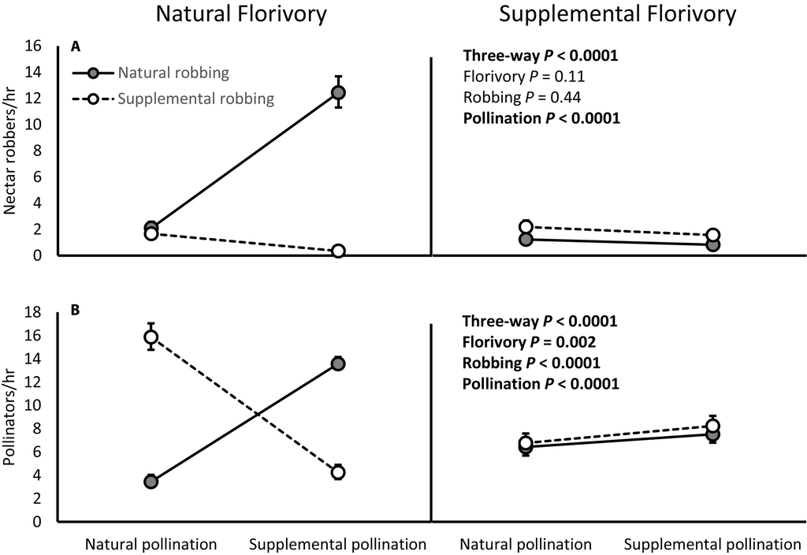

**Figure 2**

Significant three-way interactions between supplemental florivory, nectar robbing, and pollination treatments on (A) subsequent nectar robber and (B) subsequent pollinator visits to *Impatiens capensis* plants. Error bars show ± 1 standard error back-transformed from the log scale. *P* values are from Table 1; significant *P* values at *P* < 0.05 are bold.

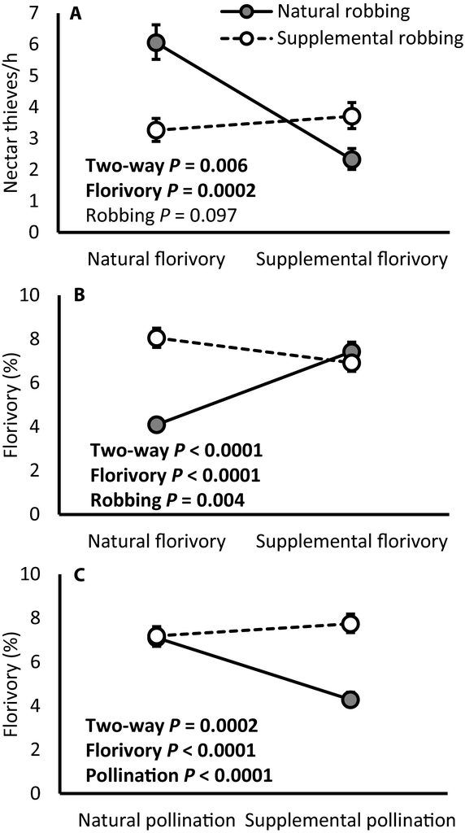

**Figure 3**

Significant two-way interactions on subsequent plant–insect interactions on *Impatiens capensis*. (A) Significant two-way interaction between nectar robbing and florivory treatments on subsequent nectar thief visitation. (B) Significant two-way interaction between nectar robbing and florivory treatments on subsequent florivory. (C) Significant two-way interaction between nectar robbing and pollination treatments on subsequent florivory. Error bars show ± 1 standard error, back-transformed from the log scale. *P* values are from Table 1; significant *P* values at *P* < 0.05 are in bold.

Subsequent leaf herbivory was least affected by floral manipulations. Only the pollination treatment affected leaf herbivory (Table 1A). Plants with supplemental pollination had approximately 25% more leaf damage (*F*<sub>8, 184</sub> = 4.9536, *P* = 0.027), with no effects on herbivore richness or density (*F* < 0.9, *P* > 0.34 for both).

### Effects on plant reproduction

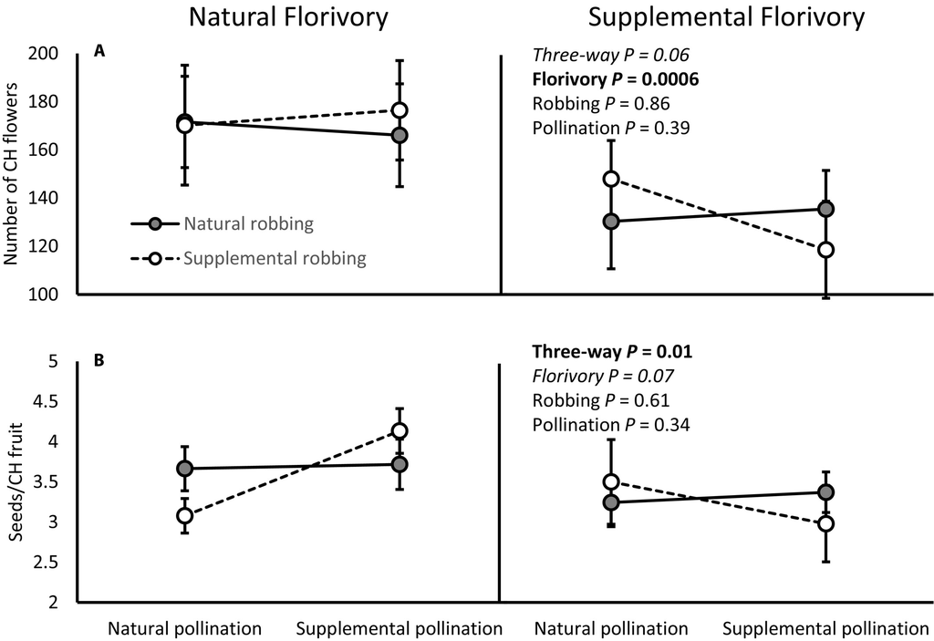

**Figure 4**

Both covariates (date of first CH flower and plant height) were significant in the analysis of plant reproduction, with taller plants that flowered earlier having more overall reproduction (Table 1A). However, neither covariate was related to seed traits (Table 1A).

## Discussion

Manipulating flower–insect interactions had no measurable impact on any of the plant growth, floral defense, or floral attractiveness traits we measured, but still had strong effects on subsequent plant–insect interactions and plant reproduction (Table 1). Experimentally increasing florivory, nectar robbing, and pollination on *I. capensis* significantly changed the behavior of subsequent interactors, including both mutualists like pollinators and antagonists like florivores. These results suggest that the composition of plant–insect relationships in a community may have significant impacts on each other, with cascading consequences for plants. Supplemental pollination even altered leaf damage by herbivores, suggesting potential systemic effects. The impact of floral visitors on subsequent leaf visitors has not been studied extensively, but one other study in the same system found that florivory reduced leaf herbivory (Soper Gorden and Adler, 2016), suggesting that floral visitors may shape leaf–insect interactions more than previously thought. The frequent non-additive effects on plant–insect interactions in this study emphasize the importance of considering the context of any plant–insect interaction to better understand when and why it happens as well as effects on plant partners, especially since such context-dependent relationships may not be intuitive (Morris et al., 2007).

Many previous studies have asked how leaf and floral antagonists affect pollinators, but very few ask whether pollinators affect antagonists. Studies that include pollinators, nectar robbers, and herbivores typically assume that antagonists affect pollinators but not vice versa (e.g., Bronstein et al., 2003; Ivey and Carr, 2005; Rusman et al., 2018). The few studies investigating how pollinators affect antagonists have mostly examined effects of increased reproductive success on fruit or seed herbivores (e.g., Herrera, 2000). By contrast, we found that supplemental hand pollination significantly increased visitation or damage by many other insects, including nectar thieves, leaf herbivores, and under some conditions, nectar robbers and pollinators. Contrary to our prediction, we found little evidence that supplemental pollination can “rescue” plants in the face of antagonisms, instead finding that many antagonists preferred hand-pollinated plants. However, increased visitation by nectar consumers (i.e., nectar robbers, thieves, and pollinators) due to supplemental pollination was somewhat surprising. In many species, pollination leads to rapid reduction in floral attractiveness within the pollinated flower, to promote cross pollination (van Doorn, 1997). These shifts in floral attractiveness may include reduced reward production and changes in volatiles, color, or floral morphology including wilting or closing (van Doorn, 1997; Sato, 2002; Nuttman and Willmer, 2003; Lucas-Barbosa et al., 2016; Ruxton and Schaefer, 2016). Other plants invest less in future flowers or even abort future flowers once successful pollination has been achieved (e.g., Albert et al., 2011; Canto et al., 2011), suggesting some effects of pollination may depend on timing. Besides direct effects on floral attractiveness or lifespan, pollinators can reduce nectar or pollen availability and increase pathogens, all of which typically decrease attractiveness to subsequent pollinators and potentially floral antagonists (e.g., Weiss, 1991; Cnaani et al., 2006; Ruxton and Schaefer, 2016). In some protandrous species with a short female phase, such as *I. capensis*, pollination may have no effect on floral attractiveness (van Doorn, 1997). It is possible that the addition of pollen might alter floral scent (e.g., Dobson and Bergström, 2000), potentially changing attractiveness cues. However, we could find no record of supplemental pollination making flowers more attractive to other nectar consumers. Since pollinators had no effect on any floral attractive or defense traits we measured (Table 1), it is unclear why plants with hand-pollinated flowers were consistently more attractive to subsequent insect visitors, including leaf herbivores that are, presumably, not as tied to floral traits as floral visitors. Regardless of the mechanism, plants with supplemental pollination were more likely to receive more subsequent pollinator visits, as well as increased visitation by nectar larcenists, highlighting the need for further study of pollination effects on subsequent plant visitors.

As predicted, we found that florivory overwhelmed the effects of both supplemental nectar robbing and hand pollination on subsequent pollinator visits (Fig. 2B), nectar robbers (Fig. 2A), and nectar thieves (Fig. 3A), suggesting that nectar consumers may use florivore-caused signals to make visitation decisions from a distance. This reduction in floral visitation after florivory may be partly explained by decreased CH flower production in response to supplemental florivory (Fig. 4A); pollinators are known to respond to flower number when making visitation choices (Chittka and Raine, 2006). While other studies have found that florivory can alter flower size or other floral traits (McCall, 2008; Liao et al., 2013; Jogesh et al., 2017), none of these were affected in our study (Table 1). In the absence of supplemental florivory, supplemental nectar robbing decreased both pollinator visitation on hand-pollinated plants (Fig. 2B) and subsequent nectar robbing (Fig. 2A), suggesting that when florivory is low, floral visitors may use nectar-robbing cues to make visitation decisions. However, the obvious trait that nectar robbers change is nectar volume (Hazlehurst and Karubian, 2016; Missagia and Alves, 2017), but we found no effect of nectar robbing on nectar production in other flowers (Table 1). It is possible the effect is driven by an unmeasured trait, such as floral volatiles.

Florivores responded to floral treatments differently than both mutualist and antagonist nectar consumers. Experimental florivory increased subsequent natural florivory while reducing pollination, nectar robbing, and nectar thieving (Figs. 2, 3). Increased florivory following floral damage is consistent with previous research in this system (Soper Gorden and Adler, 2016; but see Boyer et al., 2016), where plants with moderate to severe artificial florivory received more natural subsequent florivory than control plants. Florivores also differed from other floral visitors in their response to pollination. While other floral visitors preferred plants with supplemental pollination, florivores avoided them, especially if the plants had no supplemental florivory or nectar robbing (Fig. 3C). Together, these patterns suggest that florivores and nectar consumers are attracted to different floral traits. Indeed, a previous study in this system found that nectar consumers and florivores preferred the opposite floral traits; for example, while nectar thieves preferred redder flowers with higher levels of anthocyanins, florivores preferred yellower flowers with lower anthocyanins (Soper Gorden and Adler, 2016). This is an interesting and unexpected result, since florivores have typically been theorized to be attracted to similar traits as pollinators (McCall and Irwin, 2006), and there are several instances of traits for which this is true (e.g., volatiles: Nunes et al., 2016; flower size: Knauer and Schiestl, 2017). If pollinators and florivores prefer different floral traits, one would expect strong selection for traits that both attract pollinators and deter florivores. Yet we still see many plants with high levels of florivory. It is possible that resource availability limits plant ability to maximize pollinator-preferred traits or that there are other trade-offs limiting the benefits of traits preferred by pollinators. For example, nectar thieves and nectar robbers also both preferred pollinated plants (Table 1; Fig. 2A) and may exert conflicting selection on pollinator-preferred traits.

## Conclusions

Our results show that floral visitor behavior is heavily context dependent, with frequent significant two- and three-way interactions of floral manipulations on subsequent insect relationships with plants. Surprisingly, supplemental pollination even affected leaf damage. This result emphasizes the importance of understanding plant–insect interactions in a community context. We also found that effects on plant–insect interactions depended more on what part of the plant the insect consumes than on whether the insect is a mutualist versus antagonist. For example, nectar consumers (including both mutualistic pollinators and antagonistic nectar larcenists) had the opposite response to our treatments as petal consumers (florivores). Although our treatments did not affect any plant or floral traits measured, they significantly affected plant reproduction in a complex, non-additive manner. While the florivory treatment had arguably the largest negative impact on plant reproduction, the severity of this effect depended on whether supplemental nectar robbing and/or hand pollination were present. Taken together, our results add nuance to the growing body of literature highlighting the importance of understanding plant–insect interactions in the broader context of their communities.

## Acknowledgements

The authors thank N. Hanson and Hampshire Farm for field space. N. Shlykova, I. Showalter, and J. Frach assisted with fieldwork, and K. Henry, K. Farland, G. Garris, T. Hernon, A. Tse, K. Moran, W. Anthony, and M. Servidone helped with lab work. B. Gross, J. Etterson, members of the Etterson lab, members of the Adler lab, our reviewers, and the editors at the *American Journal of Botany* (S. Kephart, P. Diggle, and A. McPherson) provided constructive feedback on this manuscript. Funding was provided by the National Science Foundation under grant DEB-1011236 and the University of Massachusetts Plant Biology Program. Any opinions, findings, and conclusions or recommendations expressed in this material are those of the authors and do not necessarily reflect the views of the National Science Foundation.

## Data Accessibility

All data and R scripts are available from the Dryad Digital Repository: https://doi.org/10.5061/dryad.0j96d17 (Soper Gorden and Adler, 2018).

## Citing Literature

[figure not shown]

[Volume105, Issue11](https://bsapubs.onlinelibrary.wiley.com/toc/15372197/2018/105/11)

November 2018

Pages 1835-1846

beta

powered by

[figure not shown]

### Metrics

All-time Citations: 4

### Details

© 2018 Botanical Society of America

[figure not shown]

- [Author manuscript](https://bsapubs.onlinelibrary.wiley.com/doi/am-pdf/10.1002/ajb2.1182)

### Research funding

- National Science Foundation. Grant Number: DEB-1011236
- University of Massachusetts Plant Biology Program

### Keywords

- anthocyanins
- Balsaminaceae
- [condensed tannins](https://bsapubs.onlinelibrary.wiley.com/action/doSearch?field1=Keyword&text1=condensed%20tannins)
- [factorial design](https://bsapubs.onlinelibrary.wiley.com/action/doSearch?field1=Keyword&text1=factorial%20design)
- florivory
- [*Impatiens capensis*](https://bsapubs.onlinelibrary.wiley.com/action/doSearch?field1=Keyword&text1=%0AImpatiens%20capensis%0A)
- mutualism
- [nectar robbing](https://bsapubs.onlinelibrary.wiley.com/action/doSearch?field1=Keyword&text1=nectar%20robbing)
- [non-additive effects](https://bsapubs.onlinelibrary.wiley.com/action/doSearch?field1=Keyword&text1=non%E2%80%90additive%20effects)
- [supplemental pollination](https://bsapubs.onlinelibrary.wiley.com/action/doSearch?field1=Keyword&text1=supplemental%20pollination)

### Publication History

- Issue Online: 18 November 2018
- Version of Record online: 30 October 2018
- Manuscript accepted: 16 August 2018
- Manuscript received: 20 February 2018